# Runs of luck

Tyler J Burns

5/26/2021

```r
library(tidyverse)
```

## Introduction

| *Nobody can be lucky all the time;* *don’t think you’ve been abandoned in your prime,* *but rather that you’re saving up your ration.* |
| --- |
| Piet Hein, [Grooks](https://www.phys.ufl.edu/~thorn/grooks.html) |

This markdown will simulate coin tosses and ask simple questions about runs of consectuive heads or tails. We will start by asking if luck predicts more luck, which will allow us to discover the concept of the Gambler’s Fallacy. We will then look at maximum runs of luck given a specific number of coin tosses, which will allow us to come across the concept of the fat-tailed distribution, which in turn is very common in nature.

## Runs of luck 1: does luck predict more luck?

This will be the first section where we take the simulated coin tosses and analyze instances where there are a run of heads or a run of tails. We’re going to attack the concept of the Gambler’s Fallacy first. The problem and its magnitude is explained below:

[output not shown]

Below, I wrote a function that flips a coin until there is a run of a specified number of heads in a row. The function flips a coin one more time after that and records only that last result. If 5 heads in a row leads to the 6th flip being also heads more often than not, then we will see it. If this is not the case, then there will be nearly as many heads as tails.

```r
#' @title n run trial
#' @description Flips a fair coin (0 or 1 random number generator) over and over until the number of consective 1's reaches n times. Then flips a coin one more time. Returns a vector that contains the initial flips plus the final flip.
#' @param n The number of consecutive 1's that will halt the iteration
#' @return A list where the first element is the initial binary vector generated and the second element is the flip that happens at the end of the specified run of n-heads consecutively generated.
NRunTrial <- function(n) {
    curr_run <- 0
    count <- 0
    curr_flips <- c()
    while (curr_run < n) {
        count <- count + 1
        flip <- sample(x = c(0, 1),
                   size = 1,
                   replace = FALSE)
        curr_flips <- c(curr_flips, flip)

        if(count > 1) {
            if (flip == 1 & curr_flips[count - 1] == 1) {
                curr_run <- curr_run + 1
            } else if(flip == 1 & curr_flips[count - 1] == 0) {
                curr_run <- 1
            } else if(flip == 0) {
                curr_run <- 0
            }
        } else {
            if(flip == 1) {
                curr_run <- 1
            } else {
                curr_run <- 0
            }
        }
    }
    flip <- sample(x = c(0, 1),
                   size = 1,
                   replace = FALSE)
    return(list(curr_flips, flip))
}

test <- NRunTrial(n = 5)
test[[1]]
```

```
##   [1] 1 1 0 0 0 0 0 0 0 0 0 1 1 1 1 0 1 0 0 0 1 0 1 0 1 0 0 1 0 0 1 0 0 1 1 1 0
##  [38] 1 1 0 0 0 1 1 1 1 0 1 1 0 1 1 0 1 0 1 0 1 1 1 0 1 1 0 0 0 0 0 0 0 0 0 1 1
##  [75] 0 1 1 1 1 0 0 1 0 1 1 0 1 0 0 0 0 0 0 1 1 0 1 0 1 1 1 1 0 0 1 1 1 0 0 0 0
## [112] 0 0 1 1 0 0 1 0 0 0 1 1 1 1 0 0 1 1 0 0 0 1 1 1 0 0 1 1 1 0 0 0 1 1 0 1 0
## [149] 1 0 0 1 1 0 0 1 0 0 1 1 0 1 1 1 1 0 0 1 0 1 0 0 0 0 0 1 0 1 1 1 0 1 1 0 1
## [186] 1 0 1 1 1 1 0 0 1 1 1 0 0 0 0 0 1 0 0 1 0 0 1 0 1 1 1 1 0 0 0 1 1 0 1 0 0
## [223] 0 1 1 1 1 0 0 0 0 0 0 1 1 0 1 1 1 1 0 1 0 1 0 1 0 0 1 0 0 0 1 0 0 0 1 0 1
## [260] 0 1 0 1 0 1 1 1 1 0 1 0 1 0 1 0 1 1 0 1 1 1 1 0 1 1 0 0 0 1 1 0 1 1 0 1 0
## [297] 0 0 0 0 1 0 0 0 0 1 1 0 0 1 0 0 0 1 0 1 1 0 0 0 0 1 0 0 0 1 1 0 0 1 1 1 0
## [334] 0 0 0 1 0 0 1 0 0 0 0 0 0 1 0 0 1 0 1 0 0 1 0 1 0 0 0 1 1 1 1 0 1 0 0 0 0
## [371] 1 1 1 0 0 1 1 1 1 1
```

```r
test[[2]]
```

```
## [1] 1
```

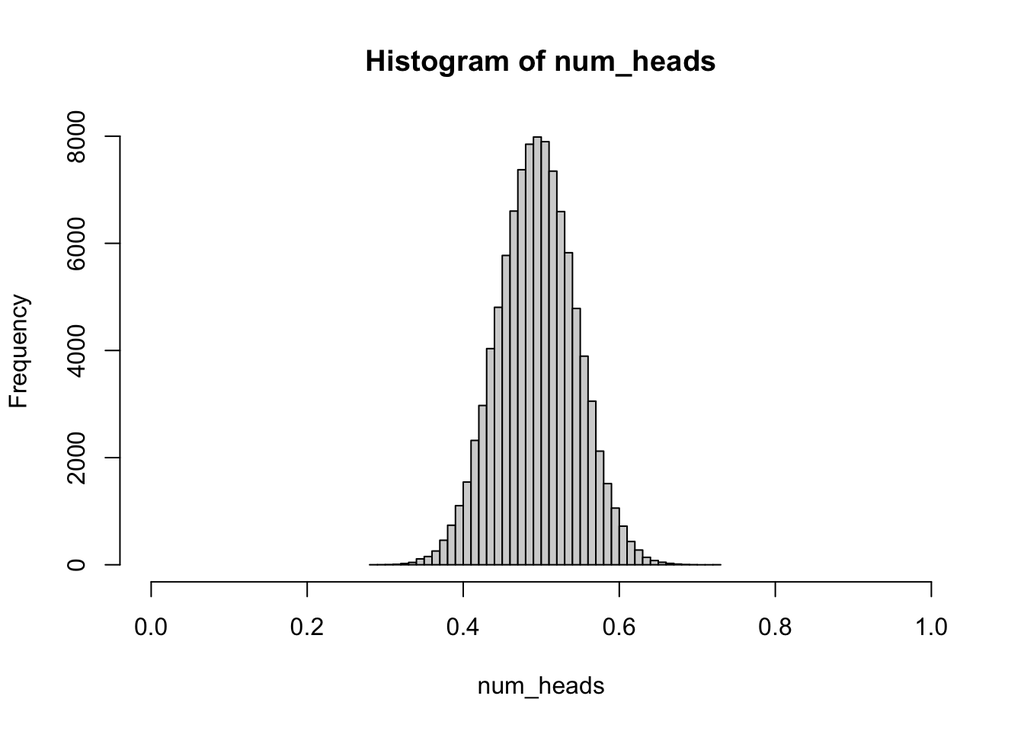

```r
set.seed(1)

n_sessions <- 100000

# Wait until we get three consecutive heads, then flip again.
num_heads <- lapply(seq(n_sessions), function(i) {
    result <- lapply(seq(100), function(j) {
        NRunTrial(n = 3)[[2]]
    }) %>% unlist()
    result <- sum(result)/length(result)
    return(result)
}) %>% unlist()

# Histogram
hist(num_heads, breaks = 50, xlim = c(0, 1))
```

```r
mean(num_heads)
```

```
## [1] 0.4996731
```

```r
sd(num_heads)
```

```
## [1] 0.04993156
```

If gamblers ran these computational experiments prior to going to the casino, perhaps they would save a little bit of money.

## Runs of luck 2: maximum runs

[output not shown]

When flipping coins, sometimes you get “runs of luck” where you have a string of heads or a string of tails that seems to defy the odds. We see this often in basketball when a certain player is “on fire” and can’t seem to miss a basket. Back to the coin tosses, we can calculate the probability of getting n heads in a row as multiplying 1/2 n times, or:

$$1/2^{n}$$

We’re going to ask a slightly different but related question here: if we flip a coin n times, what is the maximum run of luck we will get? Note that framing the question this way allows to examine the distribution of runs of luck given a specific number of tosses. This should give you some intuition around what the odds are that you’ll defy the odds.

We program the run of luck counting below, to initially get at the relationship between number of flips and maximum run of luck, which should be similar to 1/2^n probability calculation we introduced above.

```r
set.seed(1)

#' @title Find Maximum Luck
#' @description Given a vector of coin flips (binary choices), find the largest number of 1's of 0's in a row
#' @param flips a numeric binary vector representing coin flips
#' @return a single integer denoting the maximum number of 1 or 0 in a row
FindMaxLuck <- function(flips) {
    previous_flip <- 0
    curr_count <- 0
    max_count <- 0

    for(i in flips) {
        if(i == previous_flip) {
            curr_count <- curr_count + 1
            if(curr_count > max_count) {
                max_count <- curr_count
            }
        } else {
            previous_flip <- i
            curr_count <- 1
        }
    }
    return(max_count)
}

test <- c(0, 1, 1, 0, 0, 0, 1, 0, 0)
FindMaxLuck(test)
```

```
## [1] 3
```

```r
flip_number <- c(100, 1000, 10000, 100000, 1000000)
flip_tib <- lapply(flip_number, function(i) {
    curr_flips <- sample(x = c(0, 1), size = i, replace = TRUE)
    result <- list(num_flips = i, max_luck = FindMaxLuck(curr_flips))
    return(result)
}) %>% bind_rows()


flip_tib
```

```
## # A tibble: 5 x 2
##   num_flips max_luck
##       <dbl>    <dbl>
## 1       100        7
## 2      1000       10
## 3     10000       16
## 4    100000       14
## 5   1000000       20
```

```r
1/2^20
```

```
## [1] 9.536743e-07
```

9 in 10 million, which is close to 10 in 10 million, which is 1 in 1 million, which checks out on the table above. This is a good sanity check for our simulation experiment.

We’re now going to derive a “runs of luck” distribution, the purpose of framing our original question in the way we framed it. We’ll hypothesize that this distribution looks something like the binomial distribution, in that it’s a symmetric bell curve (spoiler alert: don’t hold your breath). Below, we simulate Bernouli processes of various sizes from 100 flips to 1M flips. For each Bernouli process, we record the longest run of heads OR tails. We make no distinction between whether the longest run was heads or tails. We just care about the length of the longest run of either result.

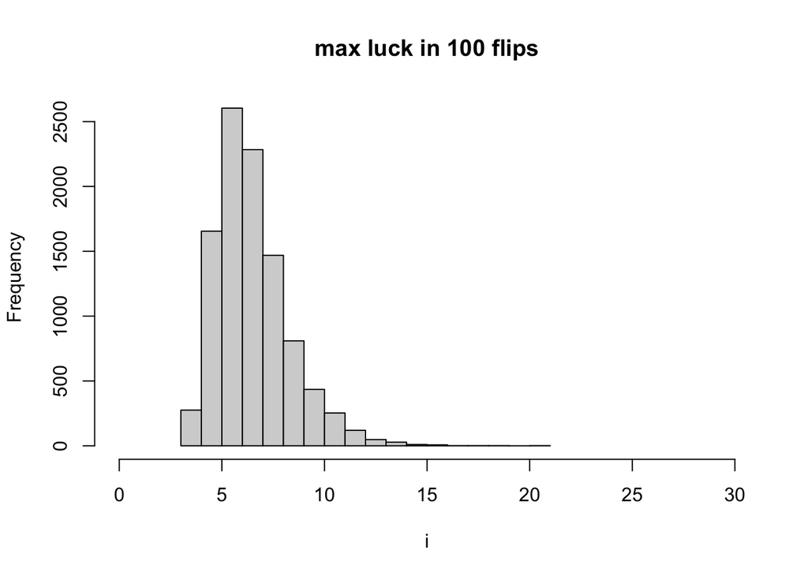

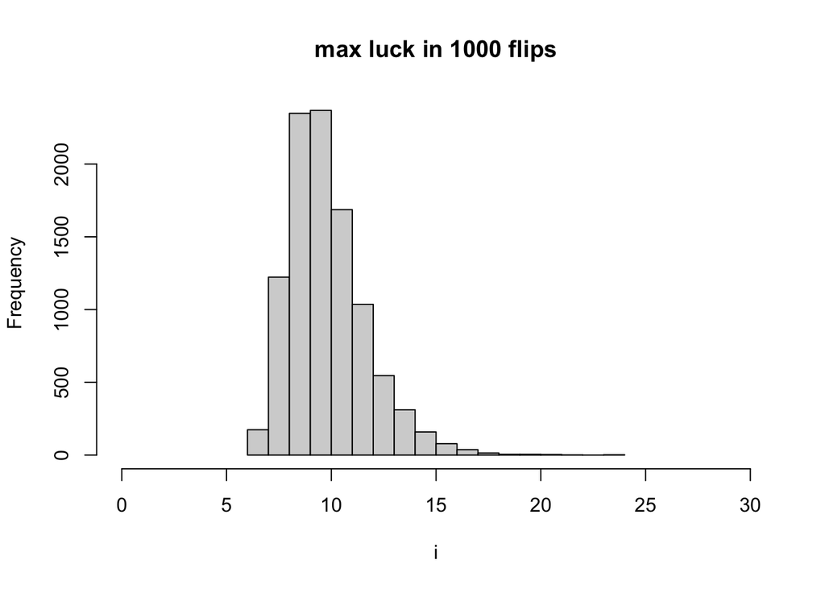

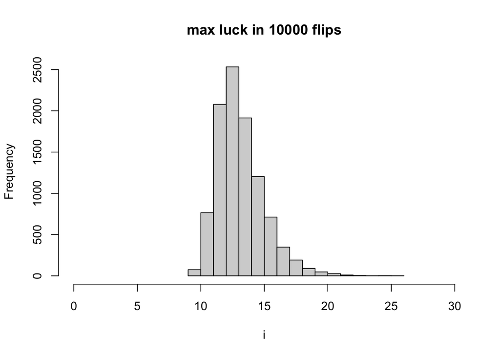

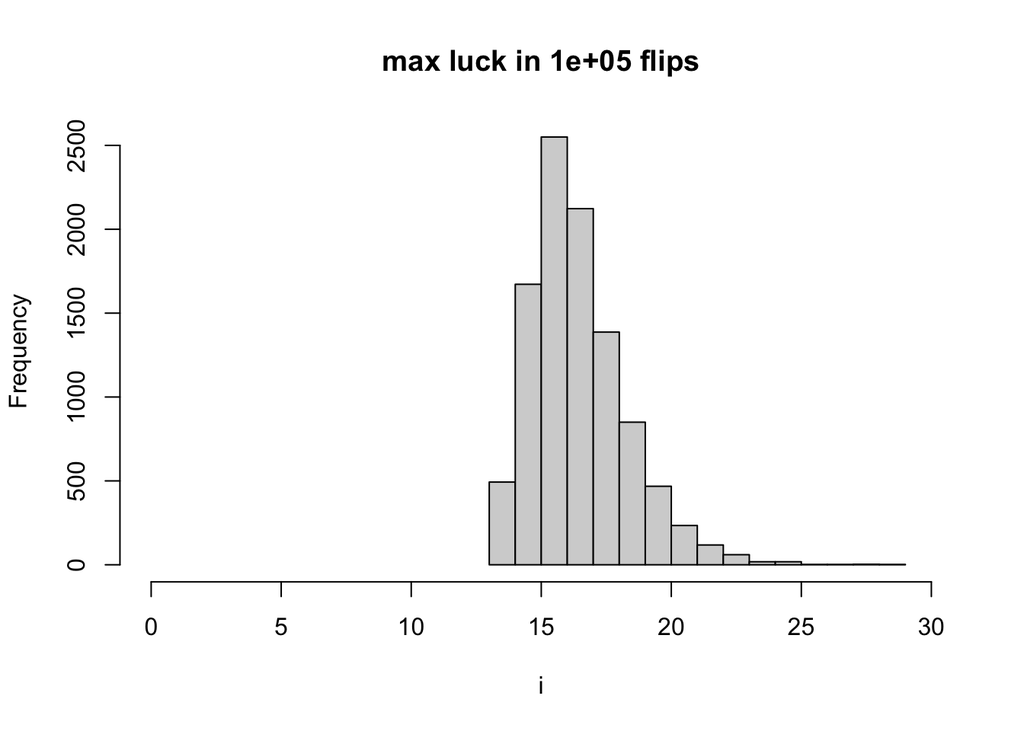

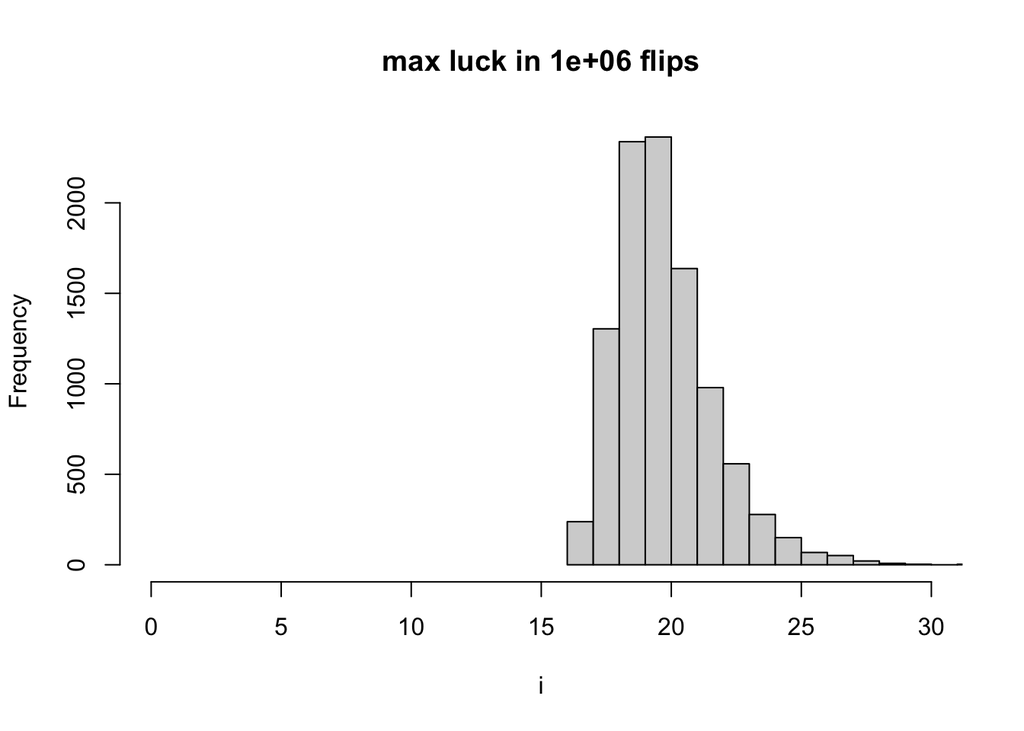

```r
flip_number <- c(100, 1000, 10000, 100000, 1000000)
flip_list <- lapply(flip_number, function(i) {

    flips <- lapply(seq(10000), function(j) {
        result <- sample(x = c(0, 1), size = i, replace = TRUE) %>% FindMaxLuck()
        return(result)
    }) %>% unlist()

    return(flips)

})
names(flip_list) <- flip_number

count <- 0
invisible(lapply(flip_list, function(i) {
    count <<- count + 1
    hist(i, breaks = 20,
         main = paste("max luck in", flip_number[count], "flips"),
         xlim = c(0, 30))
}))
```

We can see that we were right in that it does form a bell curve, but we were wrong in that it is not symmetric: it has a longer tail to the right. We can see that as the number of flips increases, the distribution shifts to the right and seems to maintain it’s shape. We output summary statistics to get a better sense of how much it shift.

These distributions are known as fat-tailed distributions, which are relatively common in nature, and they have major implications in fields like risk analysis. In general, this fat-tailed distribution belongs to a family of distributions called extreme value distributions, which is part of a branch of math called extreme value theory. This is the type of math used to predict extreme events, like 100 year floods, or epidemics. The extreme value distribution might show up if you look at the longest run of made free throws for a given basketball player, but I’ll leave that as an exercise for the reader. All this being said, extreme value theory is very important branch of mathematics, which we ran head-first into by simply looking at runs of luck in our coin toss simulations.

```r
flip_tib <- lapply(names(flip_list), function(i) {
    curr_flips <- flip_list[[i]]
    desc_stats <- summary(curr_flips) %>% as.list()
    result <- c(num_flips = i, sd = sd(curr_flips), desc_stats)
    return(result)
}) %>% bind_rows()

flip_tib$num_flips <- as.numeric(flip_tib$num_flips)
flip_tib
```

```
## # A tibble: 5 x 8
##   num_flips    sd  Min. `1st Qu.` Median  Mean `3rd Qu.`  Max.
##       <dbl> <dbl> <dbl>     <dbl>  <dbl> <dbl>     <dbl> <dbl>
## 1       100  1.79     3         6      7  6.99         8    21
## 2      1000  1.87     6         9     10 10.3         11    24
## 3     10000  1.86     9        12     13 13.6         15    26
## 4    100000  1.86    13        16     17 16.9         18    29
## 5   1000000  1.89    16        19     20 20.3         21    32
```

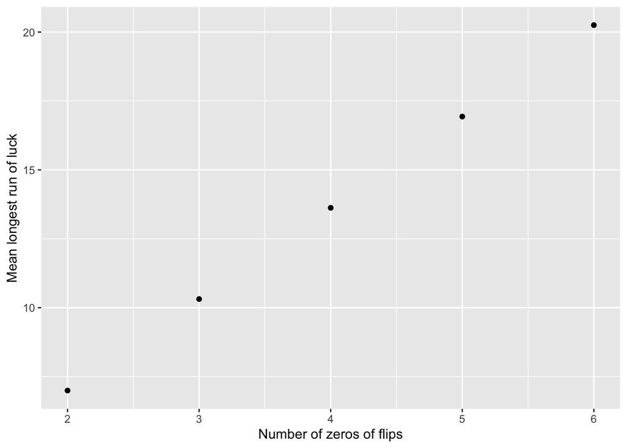

```r
# Check relationship
qplot(log10(flip_tib$num_flips), flip_tib$Mean) + labs(x = "Number of zeros of flips", y = "Mean longest run of luck")
```

```r
# Check for log10 linearity (run is always 1)
mean_slope <- lapply(seq(nrow(flip_tib)), function(i) {
    if(i == 1) {
        return(0)
    }
    result <- flip_tib[i,]$Mean - flip_tib[i - 1,]$Mean
    return(result)
}) %>% unlist()

mean_slope[-1]
```

```
## [1] 3.3202 3.3091 3.3112 3.3195
```

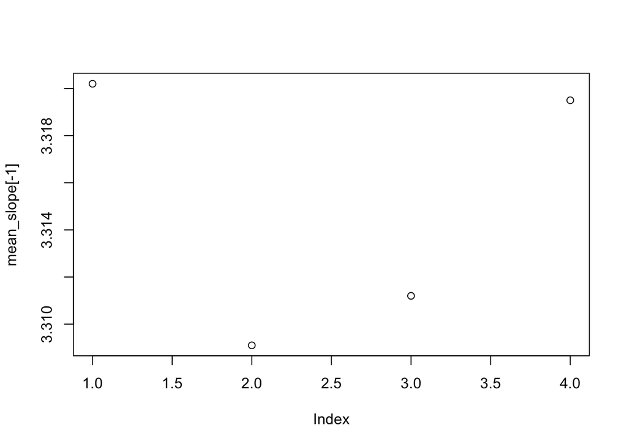

```r
plot(mean_slope[-1])
```

The relationship between the number of zeros and the mean longest run of luck is linear. Note here the team “number of zeros” is a log10 transformation of a given number, as you see in the code. Number of zeros is simpler to write, so we are sticking with this terminology. Based on the second graph, the slope appears to be converging to between 3.3 and 3.4. In other words, it is not linear to begin with, but it appears to be converging to a line with a slope of around 3.35. For large numbers, we set our equation to y = 3.35x. This means if you flip a coin one million times (which we did), then the average maximum run of luck will be 6*3.35 = 20.1. If we check empirically, the answer is close, at 20.3. For a given project, you might need more precision than this, or you might simply need to know it’s the ballpark of 3 times the number of zeros plus a few, which we were able to quickly derive before we even were examining the extreme value distributions. Furthermore, the distributions we arrived at here can tell us much more information, like the minimum and maximum run of luck one would expect given a certain number of coin tosses.

To wrap up this section, we started by asking a simple question about maximum runs of luck given a number of coin tosses. Doing the calculations with simple code led us to a simple almost linear relation between the number of zeros in the coin tosses and the maximum run of luck, which led us to the often used log transformation of data, which then led us to the extreme value distribution and extreme value theory, which introduced us to the concept of fat-tailed distributions, which are very common in nature. This gives us some potential intuition around extreme value events, like runs of luck in shooting a basketball. All of this from asking a simple question about our coin toss simulations.